# Social Control - Final Models

### Binary

```r
introduce_binary_reactance <- function(data) {
  data$is_reactance <- factor(data$reactance > 0, levels = c(FALSE, TRUE), labels = c(0, 1))
  return(data)
}



df_double <- introduce_binary_reactance(df_double)
if (use_mi) {
  for (i in seq_along(implist)) {
    implist[[i]] <- introduce_binary_reactance(implist[[i]])
  }
}


formula <- bf(
  is_reactance ~
    persuasion_self_cw + persuasion_partner_cw +
    pressure_self_cw + pressure_partner_cw +
    pushing_self_cw + pushing_partner_cw +

    persuasion_self_cb + persuasion_partner_cb +
    pressure_self_cb + pressure_partner_cb +
    pushing_self_cb + pushing_partner_cb +

    #plan_self + plan_partner +
    barriers_self_cw + barriers_self_cb +
    facilitators_self_cw + facilitators_self_cb +
    day +

    # Random effects
    (1 | dd | coupleID)

  + (1 + persuasion_self_cw + persuasion_partner_cw +
    pressure_self_cw + pressure_partner_cw +
    pushing_self_cw + pushing_partner_cw | d_u | coupleID:userID)

  , decomp = 'QR'
  #, autocor = autocor_str
  )



prior1 <- c(
  brms::set_prior("normal(0, 2.5)", class = "b")
  , brms::set_prior("normal(0, 10)", class = "Intercept", lb=0, ub=5)
  , brms::set_prior("normal(0, 2)", class = "sd", group = "coupleID", lb = 0)
)


#brms::validate_prior(
#  prior1,
#  formula = formula,
#  data = df_double,
#  family = bernoulli()
#  )



#df_minimal <- df_double[, c("AorB", all.vars(as.formula(formula)))]

is_reactance <- my_brm(
  mi = use_mi,
  imputed_data = implist,

  formula = formula,
  prior = prior1,
  data = df_double,
  family = brms::bernoulli(),
  #control = list(adapt_delta = 0.95, max_treedepth = 15),
  iter = iterations,
  warmup = warmup,
  chains = 4,
  cores = 4,
  seed = 7777,
  file = file.path("models_cache_brms", paste0("is_reactance", suffix))
  #, file_refit = 'always'
)
is_reactance_digest <- digest::digest(is_reactance)
```

```r
if (check_models) {
  check_brms(is_reactance)
  DHARMa.check_brms.all(is_reactance, integer = FALSE)
}
```

```
## # Check for Multicollinearity
##
## Low Correlation
##
##                   Term  VIF   VIF 95% CI Increased SE Tolerance
##     persuasion_self_cw 1.15 [1.13, 1.18]         1.07      0.87
##  persuasion_partner_cw 1.18 [1.15, 1.21]         1.09      0.85
##       pressure_self_cw 1.06 [1.04, 1.09]         1.03      0.95
##    pressure_partner_cw 1.05 [1.03, 1.08]         1.02      0.96
##        pushing_self_cw 1.11 [1.09, 1.14]         1.05      0.90
##     pushing_partner_cw 1.18 [1.16, 1.22]         1.09      0.84
##     persuasion_self_cb 2.09 [2.02, 2.16]         1.44      0.48
##  persuasion_partner_cb 2.23 [2.16, 2.30]         1.49      0.45
##       pressure_self_cb 2.61 [2.52, 2.70]         1.61      0.38
##    pressure_partner_cb 2.26 [2.18, 2.33]         1.50      0.44
##        pushing_self_cb 2.14 [2.07, 2.21]         1.46      0.47
##     pushing_partner_cb 2.01 [1.95, 2.08]         1.42      0.50
##       barriers_self_cw 1.29 [1.26, 1.33]         1.14      0.78
##       barriers_self_cb 1.16 [1.14, 1.19]         1.08      0.86
##   facilitators_self_cw 1.28 [1.25, 1.31]         1.13      0.78
##   facilitators_self_cb 1.11 [1.08, 1.14]         1.05      0.90
##                    day 1.07 [1.05, 1.10]         1.03      0.93
##  Tolerance 95% CI
##      [0.84, 0.89]
##      [0.82, 0.87]
##      [0.92, 0.96]
##      [0.93, 0.97]
##      [0.88, 0.92]
##      [0.82, 0.86]
##      [0.46, 0.49]
##      [0.43, 0.46]
##      [0.37, 0.40]
##      [0.43, 0.46]
##      [0.45, 0.48]
##      [0.48, 0.51]
##      [0.75, 0.80]
##      [0.84, 0.88]
##      [0.76, 0.80]
##      [0.88, 0.92]
##      [0.91, 0.95]
## # Distribution of Model Family
##
## Predicted Distribution of Residuals
##
##  Distribution Probability
##        normal         31%
##        cauchy         19%
##          beta         16%
##
## Predicted Distribution of Response
##
##   Distribution Probability
##      bernoulli         75%
##  beta-binomial         16%
##       binomial          9%
##
## Divergences:
```

```
## 0 of 40000 iterations ended with a divergence.
```

```
##
## Tree depth:
```

```
## 0 of 40000 iterations saturated the maximum tree depth of 10.
```

```
##
## Energy:
```

```
## E-BFMI indicated no pathological behavior.
```

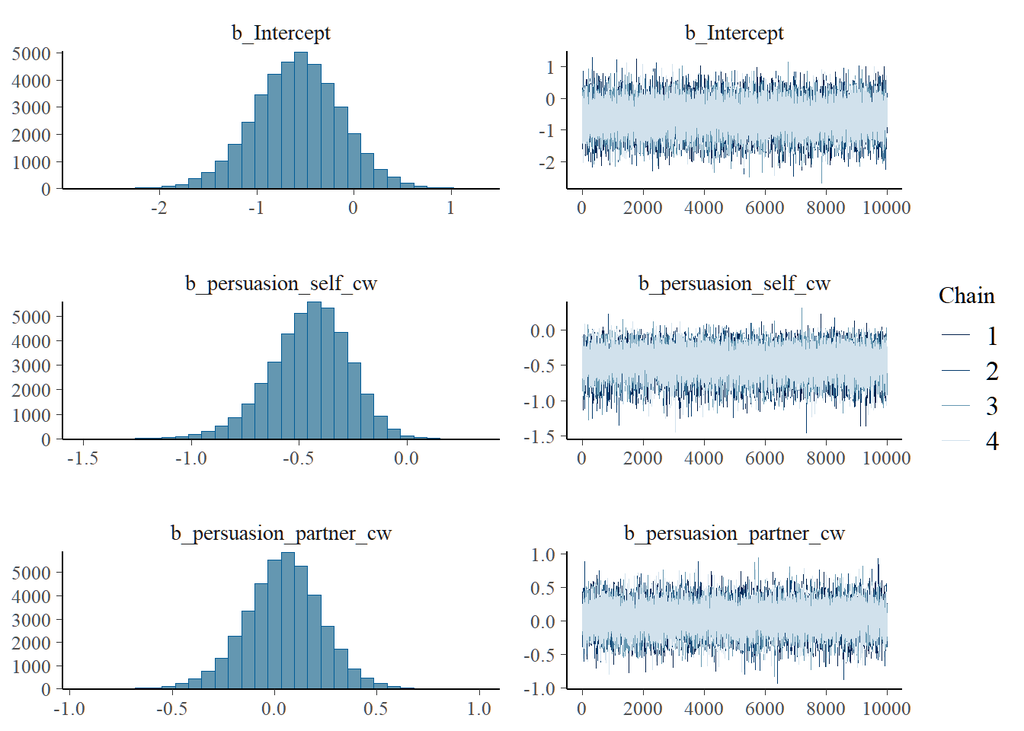

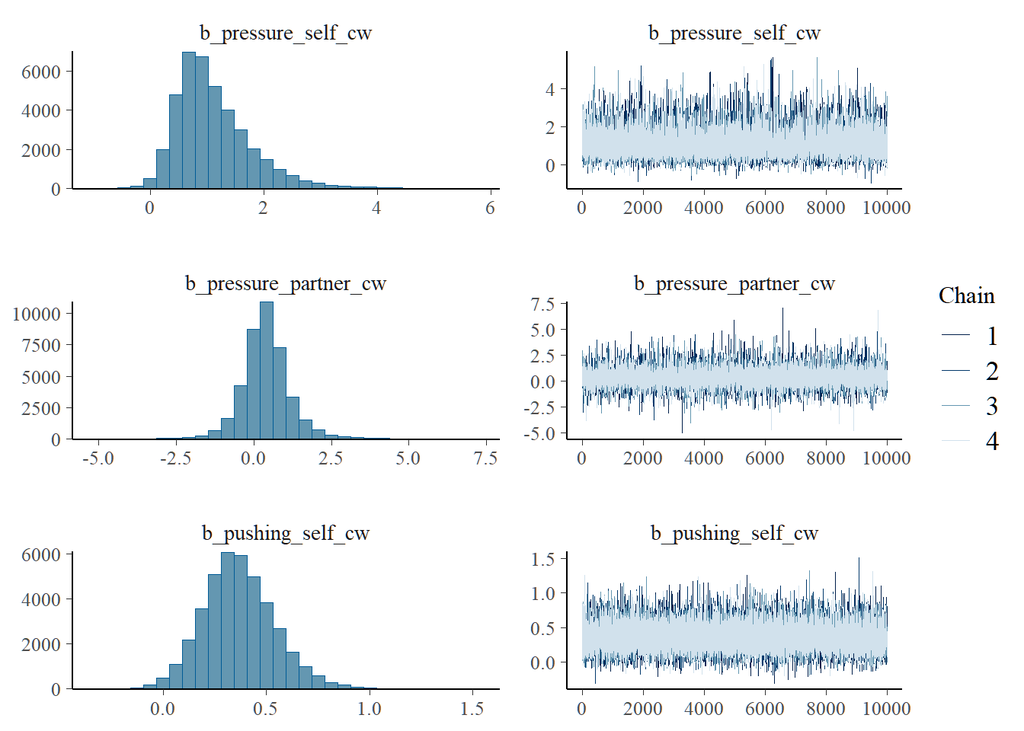

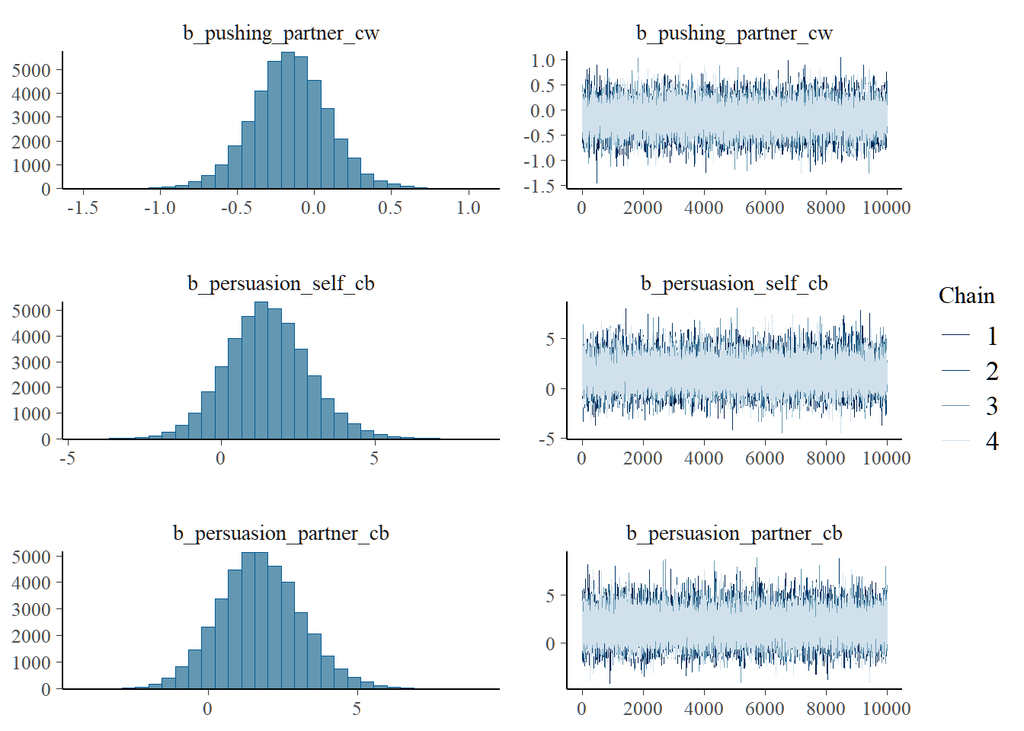

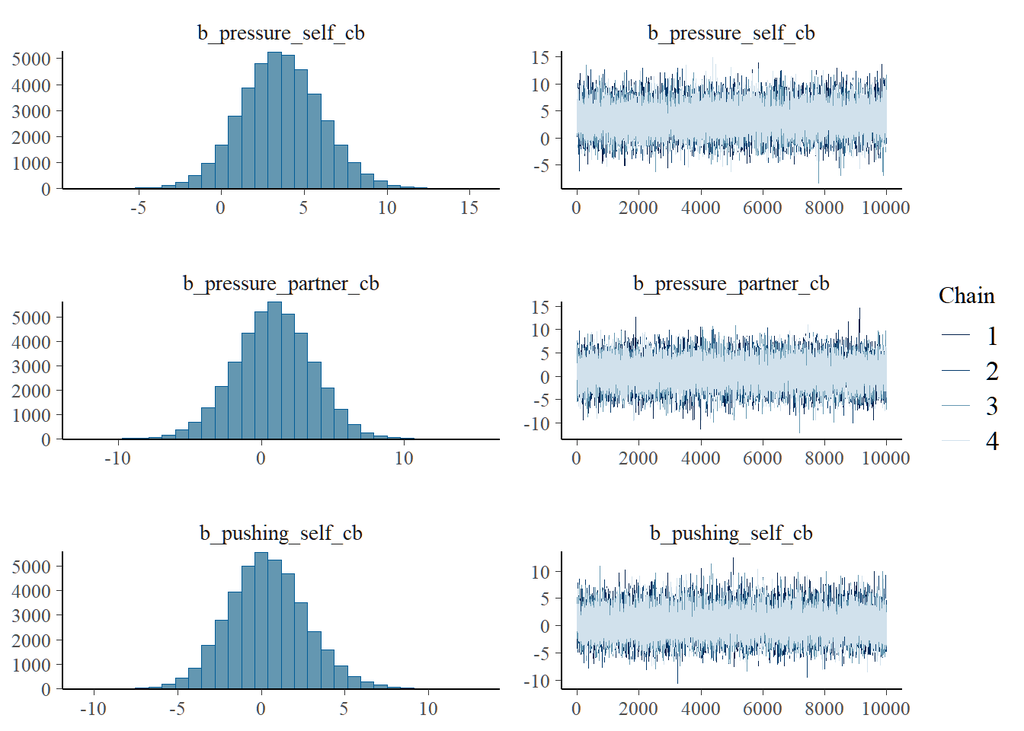

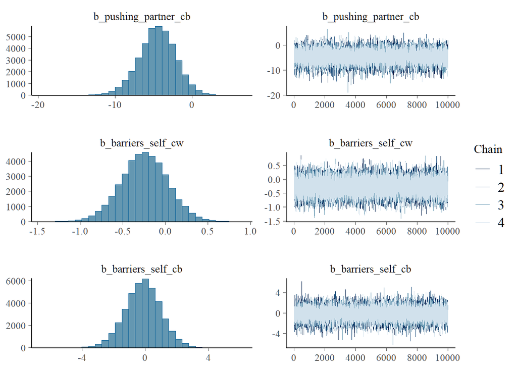

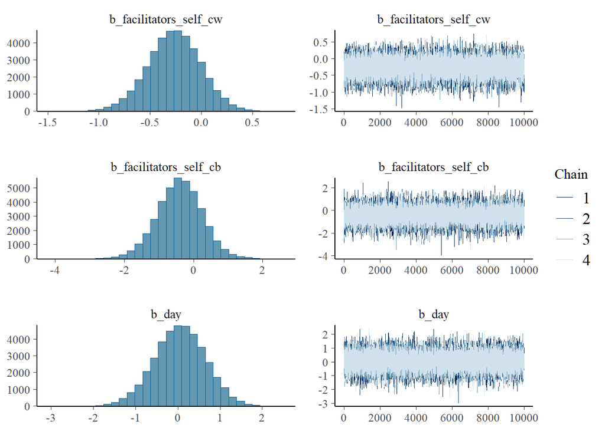

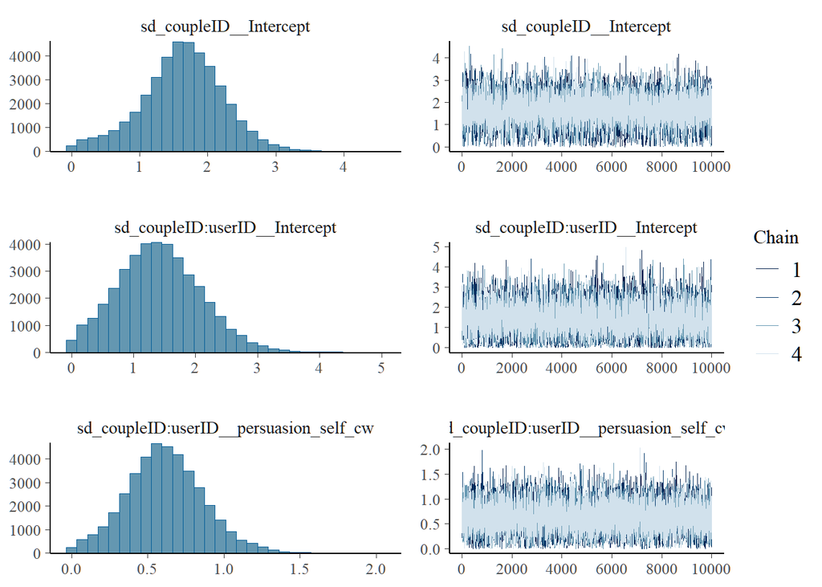

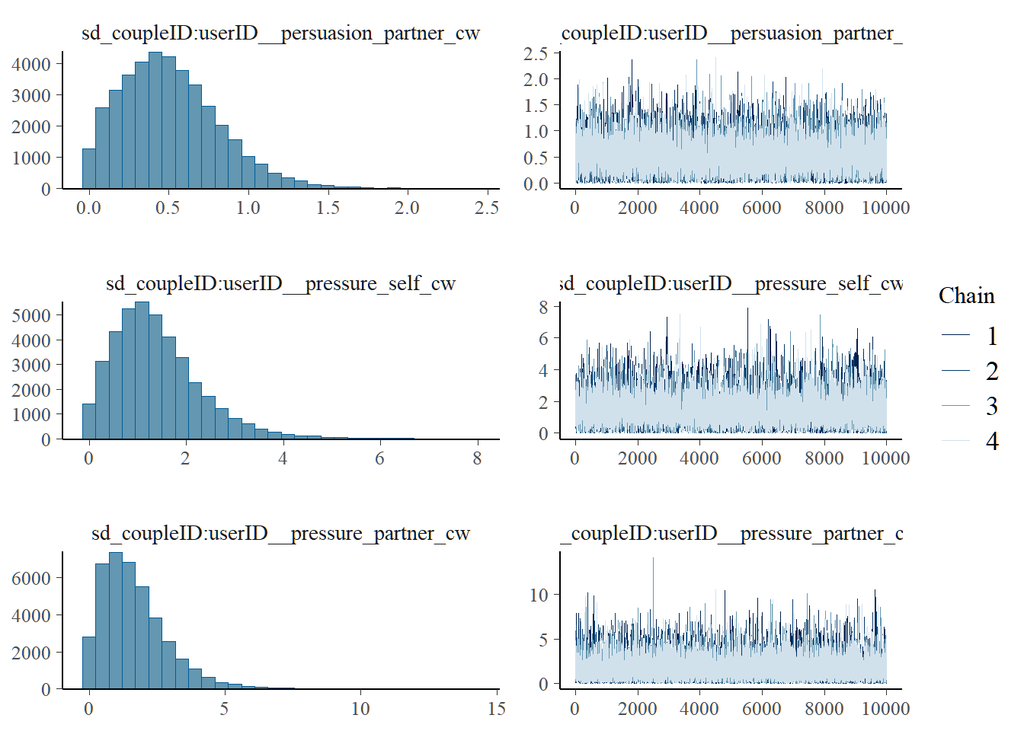

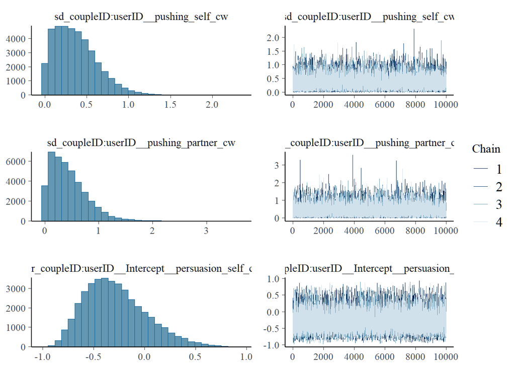

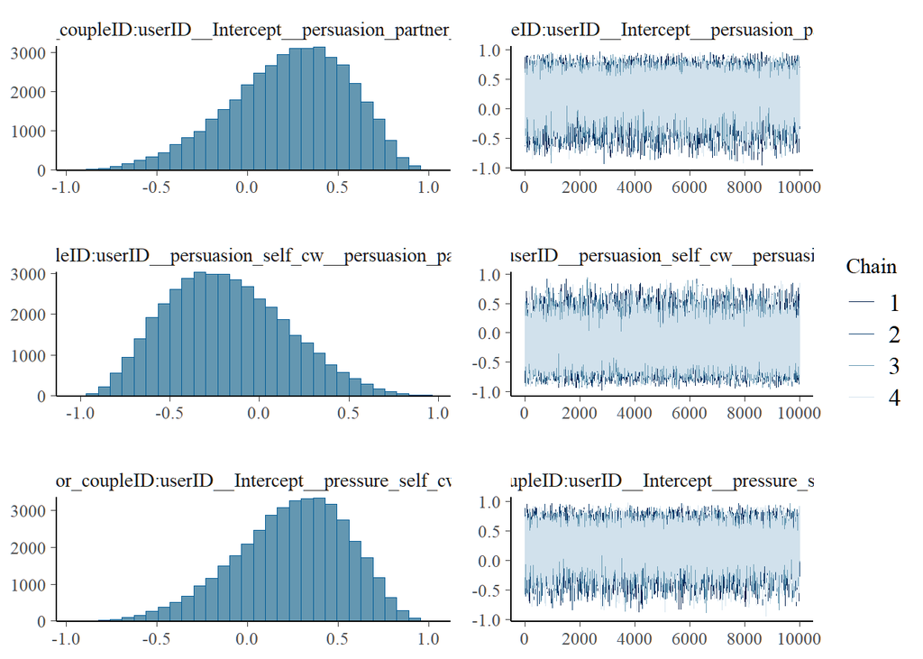

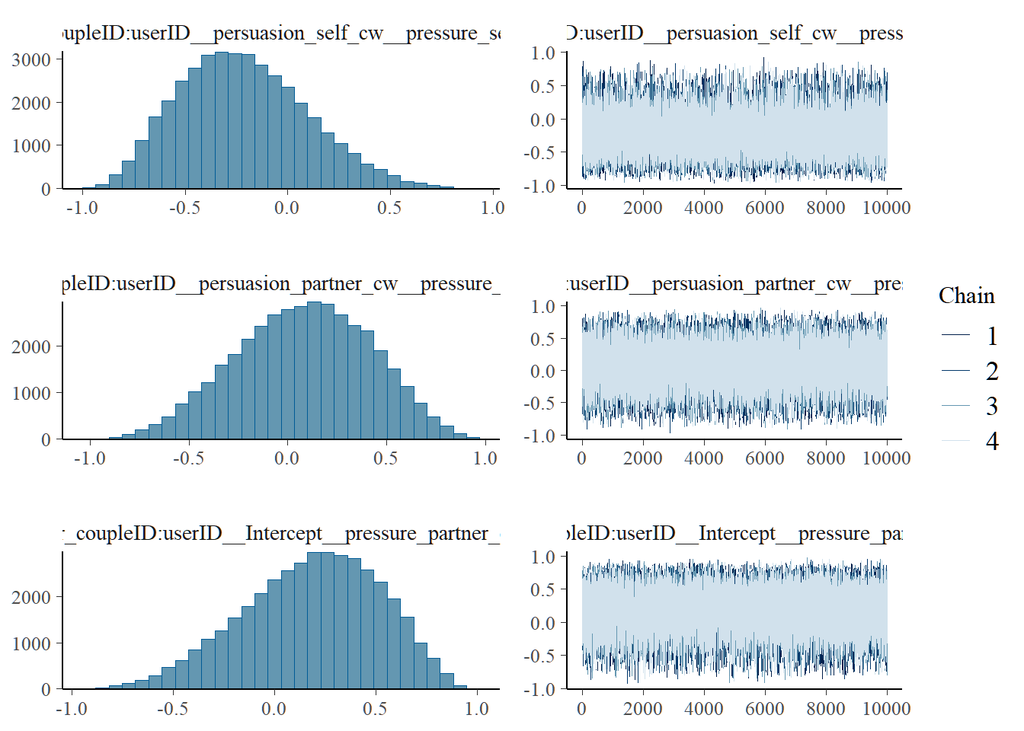

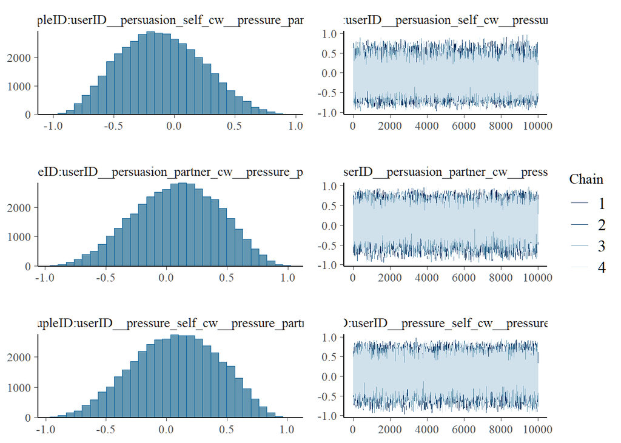

[4 more figures not shown]

```
## Using 10 posterior draws for ppc type 'ecdf_overlay' by default.
```

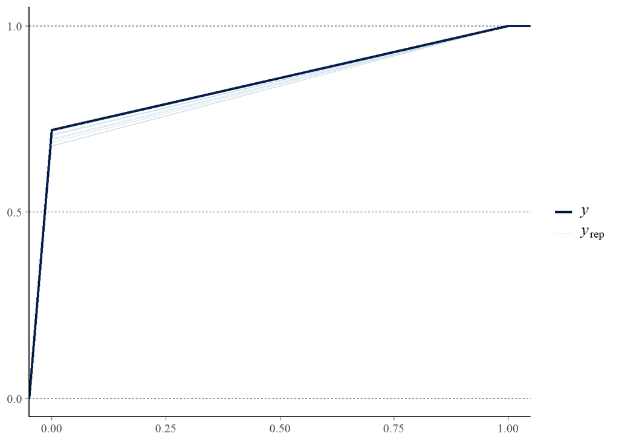

```
## Using 10 posterior draws for ppc type 'dens_overlay' by default.
```

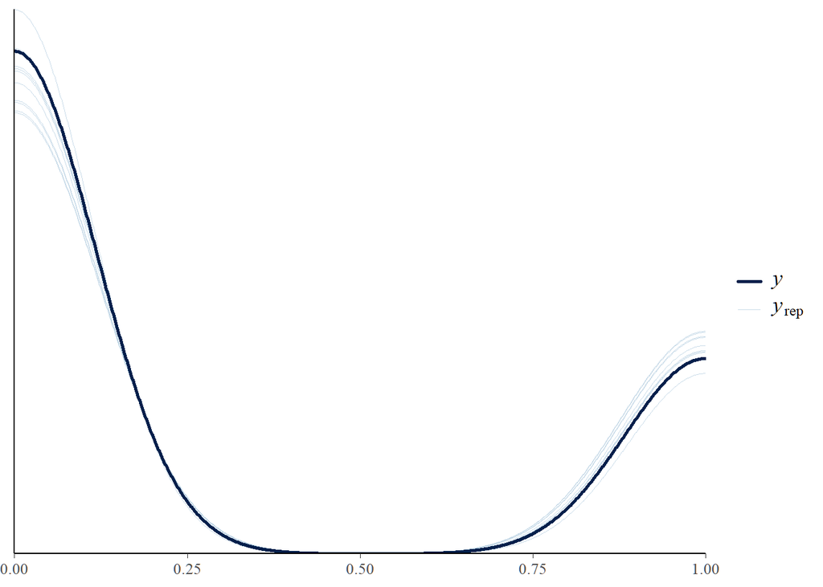

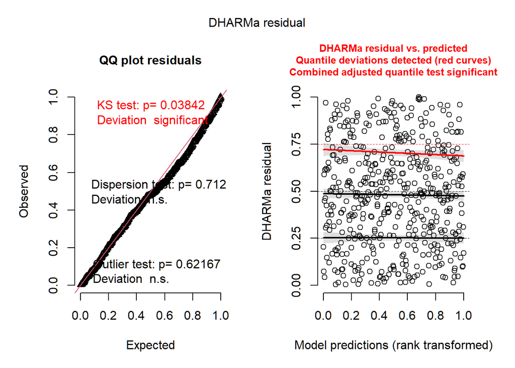

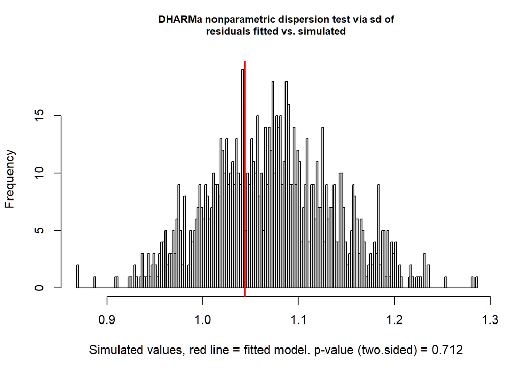

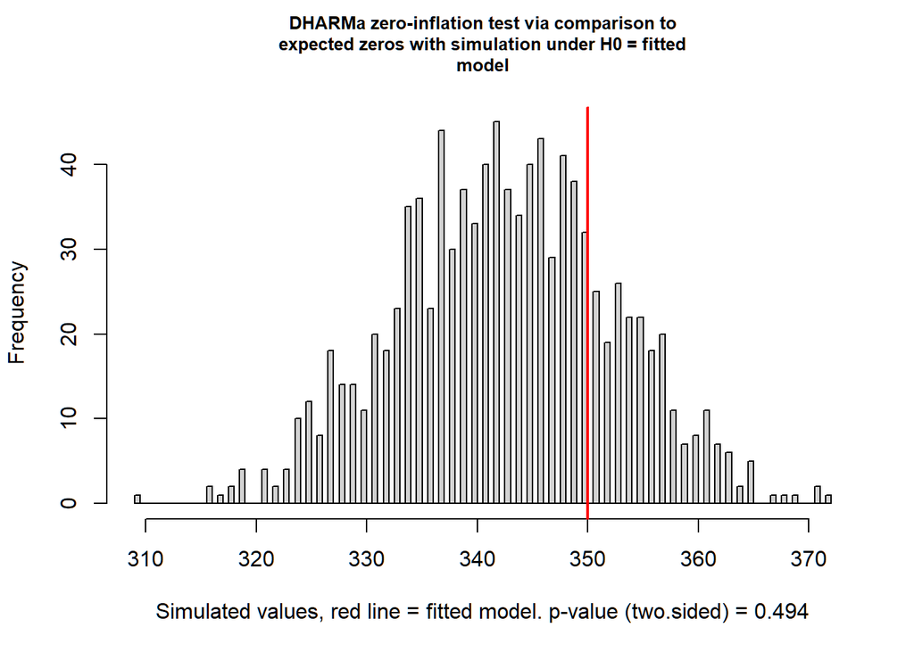

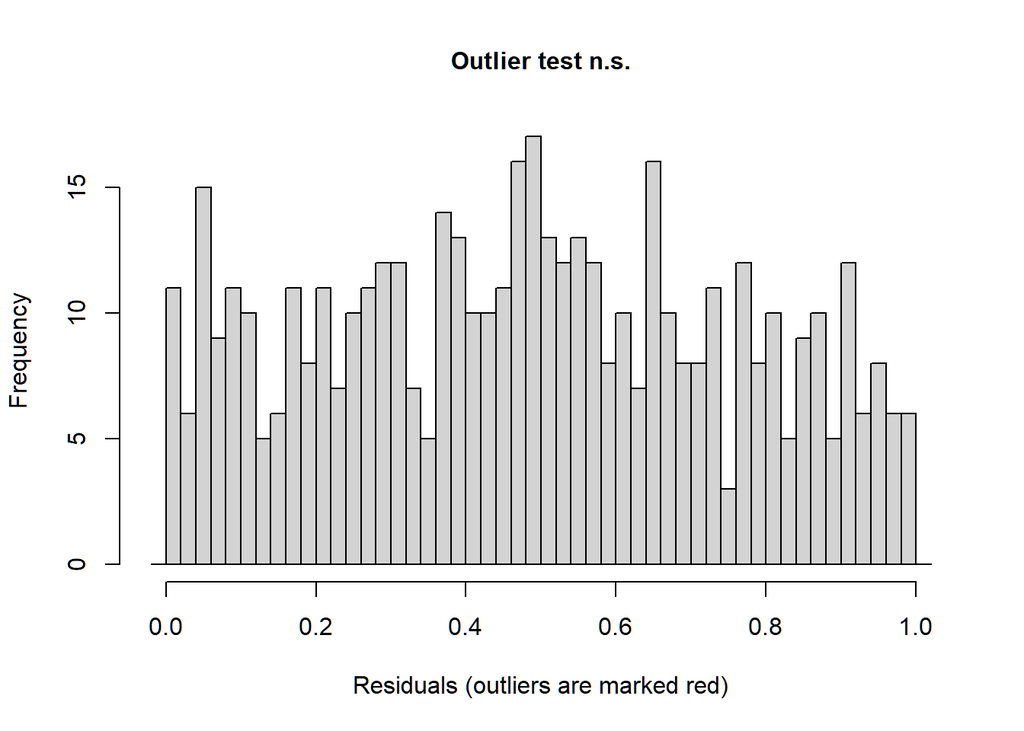

```
##
##  DHARMa outlier test based on exact binomial test with approximate
##  expectations
##
## data:  model.check
## outliers at both margin(s) = 1, observations = 486, p-value = 0.6217
## alternative hypothesis: true probability of success is not equal to 0.001998002
## 95 percent confidence interval:
##  0.0000520929 0.0114105115
## sample estimates:
## frequency of outliers (expected: 0.001998001998002 )
##                                          0.002057613
```

```r
if (do_priorsense) {
  gc()
  priorsense::powerscale_sensitivity(is_reactance, variable = priorsense_vars)
  priorsense::powerscale_plot_dens(is_reactance, variable = priorsense_vars)
  priorsense::powerscale_plot_ecdf(is_reactance, variable = priorsense_vars)
  priorsense::powerscale_plot_quantities(is_reactance, variable = priorsense_vars)
}
```

```r
summary_is_reactance <- summarize_brms(
  is_reactance,
  stats_to_report = stats_to_report,
  model_rows_fixed = model_rows_fixed,
  model_rows_random = model_rows_random,
  model_rownames_fixed = model_rownames_fixed,
  model_rownames_random = model_rownames_random,
  exponentiate = T)

summary_is_reactance %>%
  print_df(rows_to_pack = rows_to_pack)
```

|  | OR | SE | 95% CI | pd | ROPE | inside ROPE | Rhat | Bulk_ESS | Tail_ESS |
| --- | --- | --- | --- | --- | --- | --- | --- | --- | --- |
| Intercept | 0.56 | 0.25 | [0.23, 1.33] | 0.908 | [0.83, 1.20] | 0.139 | 1.000 | 31713 | 31552 |
| **Within-Person Effects** |  |  |  |  |  |  |  |  |  |
| Daily individual’s experienced persuasion | 0.64** | 0.11 | [0.43, 0.88] | 0.997 | [0.83, 1.20] | 0.055 | 1.000 | 26954 | 27992 |
| Daily partner’s experienced persuasion | 1.05 | 0.19 | [0.71, 1.51] | 0.603 | [0.83, 1.20] | 0.666 | 1.000 | 43603 | 30741 |
| Daily individual’s experienced pressure | 2.67* | 1.49 | [1.19, 16.62] | 0.992 | [0.83, 1.20] | 0.023 | 1.000 | 14017 | 14207 |
| Daily partner’s experienced pressure | 1.45 | 0.89 | [0.35, 7.93] | 0.735 | [0.83, 1.20] | 0.190 | 1.000 | 28260 | 21608 |
| Daily individual’s experienced pushing | 1.43* | 0.24 | [1.05, 2.11] | 0.989 | [0.83, 1.20] | 0.131 | 1.000 | 29857 | 32335 |
| Daily partner’s experienced pushing | 0.86 | 0.20 | [0.52, 1.40] | 0.746 | [0.83, 1.20] | 0.460 | 1.000 | 45608 | 32610 |
| Day | 1.06 | 0.64 | [0.31, 3.38] | 0.536 | [0.83, 1.20] | 0.232 | 1.000 | 51768 | 28053 |
| Own action plan | NA | NA | NA | NA | NA | NA | NA | NA | NA |
| Partner action plan | NA | NA | NA | NA | NA | NA | NA | NA | NA |
| Daily barriers | 0.78 | 0.21 | [0.45, 1.33] | 0.819 | [0.83, 1.20] | 0.349 | 1.000 | 61322 | 31294 |
| Daily facilitators | 0.77 | 0.20 | [0.46, 1.26] | 0.851 | [0.83, 1.20] | 0.335 | 1.000 | 60375 | 30901 |
| Daily wear time | NA | NA | NA | NA | NA | NA | NA | NA | NA |
| **Between-Person Effects** |  |  |  |  |  |  |  |  |  |
| Mean individual’s experienced persuasion | 4.30 | 5.61 | [0.34, 70.66] | 0.872 | [0.83, 1.20] | 0.059 | 1.000 | 40946 | 29812 |
| Mean partner’s experienced persuasion | 5.46 | 7.45 | [0.39, 103.12] | 0.897 | [0.83, 1.20] | 0.048 | 1.000 | 39419 | 31766 |
| Mean individual’s experienced pressure | 34.99 | 84.24 | [0.32, 4935.22] | 0.934 | [0.83, 1.20] | 0.018 | 1.000 | 25761 | 27613 |
| Mean partner’s experienced pressure | 2.40 | 6.41 | [0.01, 425.92] | 0.632 | [0.83, 1.20] | 0.051 | 1.000 | 19210 | 27730 |
| Mean individual’s experienced pushing | 1.36 | 3.10 | [0.02, 192.54] | 0.555 | [0.83, 1.20] | 0.064 | 1.000 | 20939 | 24975 |
| Mean partner’s experienced pushing | 0.01 | 0.03 | [0.00, 1.06] | 0.973 | [0.83, 1.20] | 0.010 | 1.000 | 28078 | 28745 |
| Mean barriers | 0.88 | 0.97 | [0.09, 8.04] | 0.549 | [0.83, 1.20] | 0.132 | 1.000 | 39443 | 29078 |
| Mean facilitators | 0.67 | 0.43 | [0.18, 2.34] | 0.736 | [0.83, 1.20] | 0.190 | 1.000 | 31565 | 28660 |
| Mean wear time | NA | NA | NA | NA | NA | NA | NA | NA | NA |
| **Random Effects (Level 3 - Couple)** |  |  |  |  |  |  |  |  |  |
| L3:sd(Intercept) | 1.65 | 0.55 | [0.31, 2.77] | NA | NA | NA | 1.000 | 6514 | 6996 |
| **Random Effects (Level 2 - Couple:Person)** |  |  |  |  |  |  |  |  |  |
| L2:sd(Intercept) | 1.39 | 0.67 | [0.19, 2.79] | NA | NA | NA | 1.001 | 5506 | 9673 |
| L2:sd(Daily individual’s experienced persuasion) | 0.61 | 0.24 | [0.12, 1.15] | NA | NA | NA | 1.000 | 9304 | 10301 |
| L2:sd(Daily partner’s experienced persuasion) | 0.47 | 0.31 | [0.03, 1.21] | NA | NA | NA | 1.000 | 11445 | 16673 |
| L2:sd(Daily individual’s experienced pressure) | 1.24 | 0.82 | [0.10, 3.59] | NA | NA | NA | 1.000 | 9661 | 14326 |
| L2:sd(Daily partner’s experienced pressure) | 1.43 | 1.09 | [0.09, 4.66] | NA | NA | NA | 1.001 | 16084 | 19536 |
| L2:sd(Daily individual’s experienced pushing) | 0.33 | 0.26 | [0.02, 0.95] | NA | NA | NA | 1.000 | 11923 | 20706 |
| L2:sd(Daily partner’s experienced pushing) | 0.37 | 0.32 | [0.02, 1.24] | NA | NA | NA | 1.000 | 16786 | 22600 |
| **Additional Parameters** |  |  |  |  |  |  |  |  |  |
| sigma | NA | NA | NA | NA | NA | NA | NA | NA | NA |

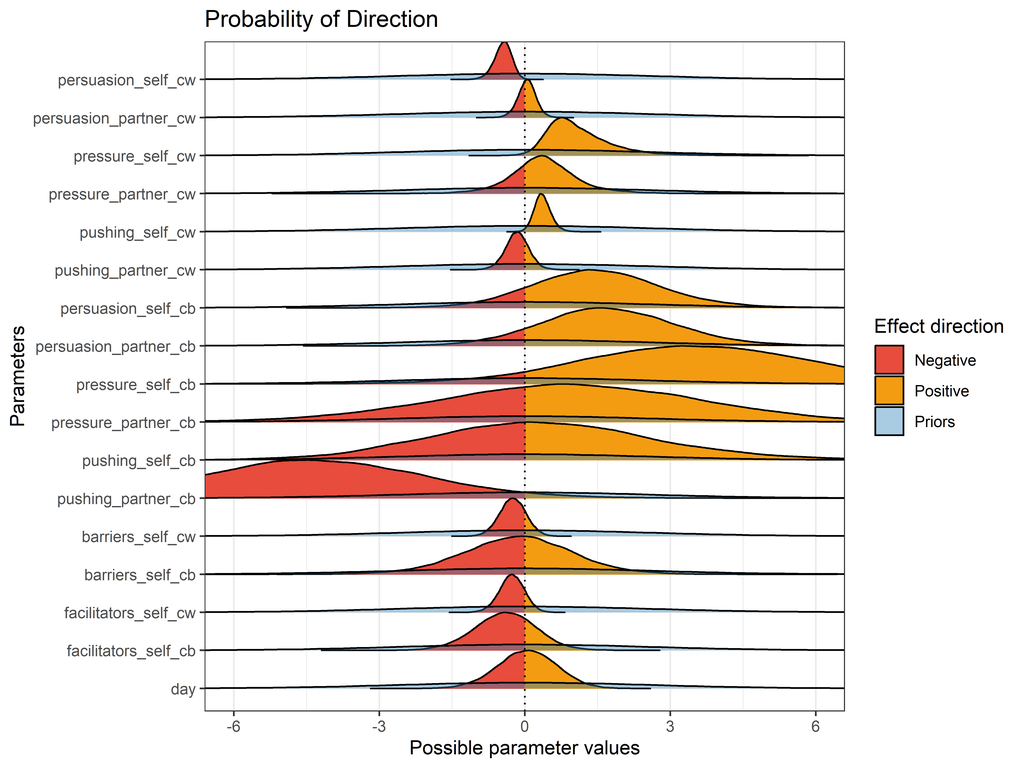

```r
plot(
  bayestestR::p_direction(is_reactance),
  priors = TRUE
) +
  coord_cartesian(xlim = c(-6, 6)) +
  theme_bw()
```

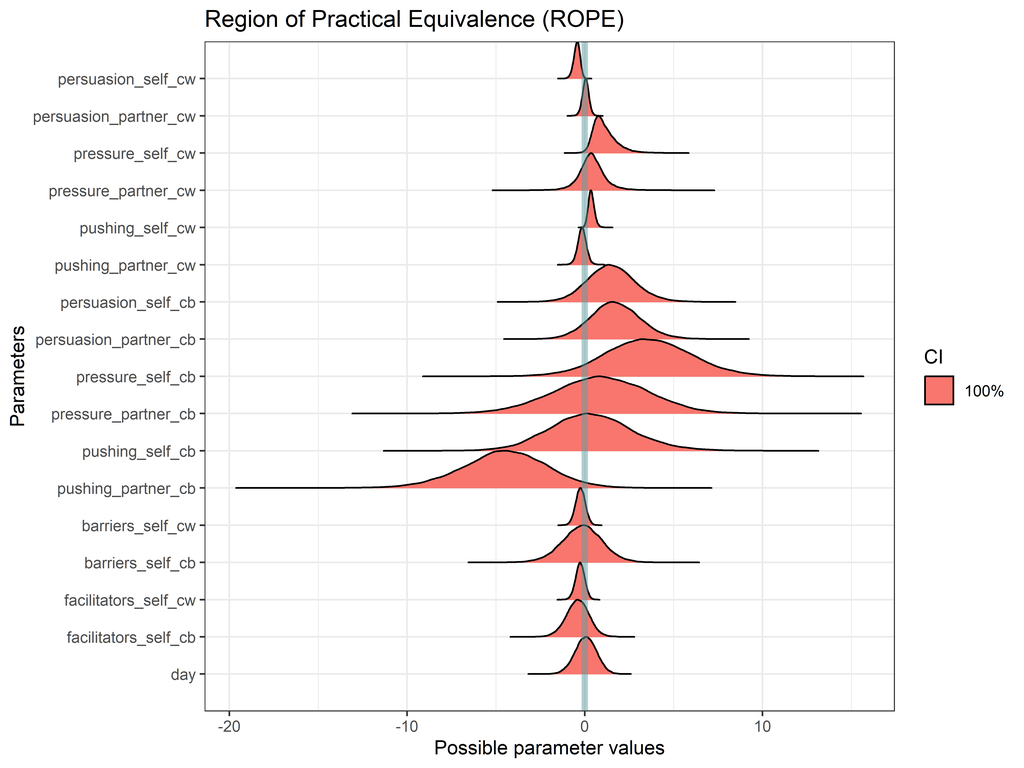

```r
plot(
  bayestestR::rope(is_reactance, ci = 1)
) + theme_bw()
```

```r
hypothesis(is_reactance, "exp(pressure_self_cw) > exp(pushing_self_cw)")
```

```
## Hypothesis Tests for class b:
##                 Hypothesis Estimate Est.Error CI.Lower CI.Upper Evid.Ratio
## 1 (exp(pressure_sel... > 0     2.95      9.51    -0.27     9.47       8.45
##   Post.Prob Star
## 1      0.89
## ---
## 'CI': 90%-CI for one-sided and 95%-CI for two-sided hypotheses.
## '*': For one-sided hypotheses, the posterior probability exceeds 95%;
## for two-sided hypotheses, the value tested against lies outside the 95%-CI.
## Posterior probabilities of point hypotheses assume equal prior probabilities.
```

# Report All Models

```r
summary_all_models <- report_side_by_side(
  pa_sub,
  pa_obj_log,
  mood_gauss,
  is_reactance,

  stats_to_report = c('CI'),
  model_rows_random = model_rows_random,
  model_rows_fixed = model_rows_fixed,
  model_rownames_random = model_rownames_random,
  model_rownames_fixed = model_rownames_fixed
)
```

[1] “pa_sub”

[1] “pa_obj_log”

[1] “mood_gauss” [1] “is_reactance”

```r
summary_all_models <- summary_all_models %>%
  print_df(rows_to_pack = rows_to_pack) %>%
  add_header_above(
    c(
      " ", "Hurdle Component" = 2, "Non-Zero Component" = 2,
      " " = 6
    )
  ) %>%
  add_header_above(
    c(" ", "Subjective MVPA Hurdle Lognormal" = 4,
      "Device-Based MVPA Log (Gaussian)" = 2,
      "Mood Gaussian" = 2,
      #"Reactance Ordinal" = 2,
      "Reactance Dichotome" = 2
    )
  )

export_xlsx(
  summary_all_models,
  rows_to_pack = rows_to_pack,
  file.path("Output", paste0("AllModels", suffix, ".xlsx")),
  merge_option = 'header',
  simplify_2nd_row = FALSE,
  line_above_rows = c(1,2),
  line_below_rows = c(-1)
)


summary_all_models
```

|  | Subjective MVPA Hurdle Lognormal Hurdle Component exp(Est.)_hu pa_sub | Subjective MVPA Hurdle Lognormal Hurdle Component 95% CI_hu pa_sub | Subjective MVPA Hurdle Lognormal Non-Zero Component exp(Est.)_nonzero pa_sub | Subjective MVPA Hurdle Lognormal Non-Zero Component 95% CI_nonzero pa_sub | Device-Based MVPA Log (Gaussian) exp(Est.) pa_obj_log | Device-Based MVPA Log (Gaussian) 95% CI pa_obj_log | Mood Gaussian Est. mood_gauss | Mood Gaussian 95% CI mood_gauss | Reactance Dichotome OR is_reactance | Reactance Dichotome 95% CI is_reactance |
| --- | --- | --- | --- | --- | --- | --- | --- | --- | --- | --- |
| Intercept | 2.71*** | [ 1.62, 4.49] | 50.57*** | [42.70, 59.73] | 123.14*** | [109.84, 137.96] | 3.79*** | [ 3.58, 4.00] | 0.56 | [0.23, 1.33] |
| **Within-Person Effects** |  |  |  |  |  |  |  |  |  |  |
| Daily individual’s experienced persuasion | 1.58*** | [ 1.27, 2.10] | 1.02 | [ 0.97, 1.07] | 1.02 | [ 0.98, 1.05] | 0.01 | [-0.03, 0.06] | 0.64** | [0.43, 0.88] |
| Daily partner’s experienced persuasion | 1.38*** | [ 1.14, 1.76] | 1.02 | [ 0.98, 1.06] | 1.02 | [ 0.99, 1.06] | 0.01 | [-0.04, 0.05] | 1.05 | [0.71, 1.51] |
| Daily individual’s experienced pressure | 0.85 | [ 0.45, 2.41] | 0.89 | [ 0.77, 1.00] | 0.96 | [ 0.88, 1.06] | -0.06 | [-0.18, 0.06] | 2.67* | [1.19, 16.62] |
| Daily partner’s experienced pressure | 1.87 | [ 0.90, 9.47] | 0.95 | [ 0.86, 1.04] | 0.97 | [ 0.90, 1.04] | -0.04 | [-0.16, 0.06] | 1.45 | [0.35, 7.93] |
| Daily individual’s experienced pushing | 1.21 | [ 0.90, 1.77] | 0.98 | [ 0.92, 1.03] | 1.02 | [ 0.97, 1.07] | 0.04 | [-0.03, 0.11] | 1.43* | [1.05, 2.11] |
| Daily partner’s experienced pushing | 1.68** | [ 1.21, 2.89] | 0.97 | [ 0.92, 1.03] | 1.01 | [ 0.97, 1.05] | 0.11** | [ 0.05, 0.18] | 0.86 | [0.52, 1.40] |
| Day | 0.95 | [ 0.61, 1.49] | 0.99 | [ 0.87, 1.12] | 0.97 | [ 0.88, 1.06] | 0.21** | [ 0.07, 0.35] | 1.06 | [0.31, 3.38] |
| Own action plan | NA | NA | NA | NA | NA | NA | NA | NA | NA | NA |
| Partner action plan | NA | NA | NA | NA | NA | NA | NA | NA | NA | NA |
| Daily barriers | 0.70*** | [ 0.57, 0.86] | 1.23*** | [ 1.14, 1.32] | 0.98 | [ 0.94, 1.03] | -0.23*** | [-0.30, -0.16] | 0.78 | [0.45, 1.33] |
| Daily facilitators | 1.31** | [ 1.07, 1.63] | 1.24*** | [ 1.18, 1.30] | 1.07*** | [ 1.03, 1.11] | 0.11*** | [ 0.05, 0.16] | 0.77 | [0.46, 1.26] |
| Daily wear time | NA | NA | NA | NA | 1.00*** | [ 1.00, 1.00] | NA | NA | NA | NA |
| **Between-Person Effects** |  |  |  |  |  |  |  |  |  |  |
| Mean individual’s experienced persuasion | 0.87 | [ 0.25, 2.98] | 1.10 | [ 0.74, 1.62] | 1.09 | [ 0.76, 1.57] | 0.11 | [-0.57, 0.78] | 4.30 | [0.34, 70.66] |
| Mean partner’s experienced persuasion | 1.42 | [ 0.41, 4.89] | 0.90 | [ 0.61, 1.32] | 0.92 | [ 0.62, 1.36] | 0.49 | [-0.19, 1.16] | 5.46 | [0.39, 103.12] |
| Mean individual’s experienced pressure | 0.24 | [ 0.04, 1.46] | 0.69 | [ 0.26, 1.75] | 1.05 | [ 0.62, 1.80] | -0.25 | [-1.12, 0.61] | 34.99 | [0.32, 4935.22] |
| Mean partner’s experienced pressure | 0.18 | [ 0.03, 1.08] | 0.49 | [ 0.19, 1.24] | 0.99 | [ 0.60, 1.63] | -0.28 | [-1.12, 0.55] | 2.40 | [0.01, 425.92] |
| Mean individual’s experienced pushing | 1.13 | [ 0.17, 7.40] | 1.38 | [ 0.66, 2.85] | 0.99 | [ 0.55, 1.77] | 0.37 | [-0.68, 1.42] | 1.36 | [0.02, 192.54] |
| Mean partner’s experienced pushing | 1.37 | [ 0.21, 9.18] | 1.80 | [ 0.88, 3.68] | 1.29 | [ 0.72, 2.34] | -0.11 | [-1.15, 0.93] | 0.01 | [0.00, 1.06] |
| Mean barriers | 0.49 | [ 0.23, 1.06] | 0.92 | [ 0.71, 1.19] | 0.83 | [ 0.65, 1.08] | -0.41 | [-0.86, 0.06] | 0.88 | [0.09, 8.04] |
| Mean facilitators | 1.67 | [ 0.96, 3.18] | 1.12 | [ 0.95, 1.32] | 0.99 | [ 0.84, 1.16] | 0.27 | [-0.03, 0.57] | 0.67 | [0.18, 2.34] |
| Mean wear time | NA | NA | NA | NA | 1.00 | [ 1.00, 1.00] | NA | NA | NA | NA |
| **Random Effects (Level 3 - Couple)** |  |  |  |  |  |  |  |  |  |  |
| L3:sd(Intercept) | 1.15 | [0.73, 1.63] | 0.26 | [0.05, 0.39] | 0.22 | [0.04, 0.35] | 0.44 | [0.15, 0.68] | 1.65 | [0.31, 2.77] |
| **Random Effects (Level 2 - Couple:Person)** |  |  |  |  |  |  |  |  |  |  |
| L2:sd(Intercept) | 0.67 | [0.35, 1.10] | 0.24 | [0.16, 0.36] | 0.29 | [0.21, 0.40] | 0.54 | [0.40, 0.73] | 1.39 | [0.19, 2.79] |
| L2:sd(Daily individual’s experienced persuasion) | 0.38 | [0.04, 0.76] | 0.12 | [0.07, 0.17] | 0.06 | [0.02, 0.10] | 0.07 | [0.01, 0.15] | 0.61 | [0.12, 1.15] |
| L2:sd(Daily partner’s experienced persuasion) | 0.30 | [0.03, 0.61] | 0.05 | [0.00, 0.11] | 0.07 | [0.02, 0.12] | 0.06 | [0.00, 0.13] | 0.47 | [0.03, 1.21] |
| L2:sd(Daily individual’s experienced pressure) | 0.67 | [0.03, 2.91] | 0.08 | [0.00, 0.30] | 0.06 | [0.00, 0.20] | 0.07 | [0.00, 0.27] | 1.24 | [0.10, 3.59] |
| L2:sd(Daily partner’s experienced pressure) | 0.97 | [0.05, 3.02] | 0.05 | [0.00, 0.18] | 0.04 | [0.00, 0.13] | 0.07 | [0.00, 0.23] | 1.43 | [0.09, 4.66] |
| L2:sd(Daily individual’s experienced pushing) | 0.55 | [0.05, 1.27] | 0.05 | [0.00, 0.14] | 0.08 | [0.01, 0.14] | 0.09 | [0.01, 0.20] | 0.33 | [0.02, 0.95] |
| L2:sd(Daily partner’s experienced pushing) | 0.55 | [0.03, 1.62] | 0.05 | [0.00, 0.13] | 0.04 | [0.00, 0.10] | 0.09 | [0.01, 0.18] | 0.37 | [0.02, 1.24] |
| **Additional Parameters** |  |  |  |  |  |  |  |  |  |  |
| sigma | NA | NA | 0.64 | [0.62, 0.67] | 0.51 | [0.49, 0.53] | 0.82 | [0.79, 0.85] | NA | NA |

```r
report::report_system()
```

Analyses were conducted using the R Statistical language (version 4.4.2; R Core Team, 2024) on Windows 11 x64 (build 26100)

```r
report::report_packages()
```

- rmarkdown (version 2.29; Allaire J et al., 2024)
- beepr (version 2.0; Bååth R, 2024)
- R.methodsS3 (version 1.8.2; Bengtsson H, 2003)
- R.oo (version 1.27.0; Bengtsson H, 2003)
- R.utils (version 2.12.3; Bengtsson H, 2023)
- brms (version 2.22.0; Bürkner P, 2017)
- posterior (version 1.6.0; Bürkner P et al., 2024)
- extrafont (version 0.19; Chang W, 2023)
- digest (version 0.6.37; Eddelbuettel D, 2024)
- Rcpp (version 1.0.13.1; Eddelbuettel D et al., 2024)
- bayesplot (version 1.11.1; Gabry J, Mahr T, 2024)
- lubridate (version 1.9.3; Grolemund G, Wickham H, 2011)
- DHARMa (version 0.4.7; Hartig F, 2024)
- rlang (version 1.1.4; Henry L, Wickham H, 2024)
- tidybayes (version 3.0.7; Kay M, 2024)
- wbCorr (version 0.1.22; Küng P, 2023)
- see (version 0.9.0; Lüdecke D et al., 2021)
- tibble (version 3.2.1; Müller K, Wickham H, 2023)
- patchwork (version 1.3.0; Pedersen T, 2024)
- R (version 4.4.2; R Core Team, 2024)
- openxlsx (version 4.2.7.1; Schauberger P, Walker A, 2024)
- plotly (version 4.10.4; Sievert C, 2020)
- ggplot2 (version 3.5.2; Wickham H, 2016)
- forcats (version 1.0.0; Wickham H, 2023)
- stringr (version 1.5.1; Wickham H, 2023)
- rvest (version 1.0.4; Wickham H, 2024)
- tidyverse (version 2.0.0; Wickham H et al., 2019)
- readxl (version 1.4.3; Wickham H, Bryan J, 2023)
- dplyr (version 1.1.4; Wickham H et al., 2023)
- purrr (version 1.0.2; Wickham H, Henry L, 2023)
- readr (version 2.1.5; Wickham H et al., 2024)
- xml2 (version 1.3.6; Wickham H et al., 2023)
- tidyr (version 1.3.1; Wickham H et al., 2024)
- ggridges (version 0.5.6; Wilke C, 2024)
- knitr (version 1.49; Xie Y, 2024)
- kableExtra (version 1.4.0; Zhu H, 2024)

```r
report::cite_packages()
```

- Allaire J, Xie Y, Dervieux C, McPherson J, Luraschi J, Ushey K, Atkins A, Wickham H, Cheng J, Chang W, Iannone R (2024). *rmarkdown: Dynamic Documents for R*. R package version 2.29, https://github.com/rstudio/rmarkdown. Xie Y, Allaire J, Grolemund G (2018). *R Markdown: The Definitive Guide*. Chapman and Hall/CRC, Boca Raton, Florida. ISBN 9781138359338, https://bookdown.org/yihui/rmarkdown. Xie Y, Dervieux C, Riederer E (2020). *R Markdown Cookbook*. Chapman and Hall/CRC, Boca Raton, Florida. ISBN 9780367563837, https://bookdown.org/yihui/rmarkdown-cookbook.
- Bååth R (2024). *beepr: Easily Play Notification Sounds on any Platform*. R package version 2.0, https://github.com/rasmusab/beepr.
- Bengtsson H (2003). “The R.oo package - Object-Oriented Programming with References Using Standard R Code.” In Hornik K, Leisch F, Zeileis A (eds.), *Proceedings of the 3rd International Workshop on Distributed Statistical Computing (DSC 2003)*. https://www.r-project.org/conferences/DSC-2003/Proceedings/Bengtsson.pdf.
- Bengtsson H (2003). “The R.oo package - Object-Oriented Programming with References Using Standard R Code.” In Hornik K, Leisch F, Zeileis A (eds.), *Proceedings of the 3rd International Workshop on Distributed Statistical Computing (DSC 2003)*. https://www.r-project.org/conferences/DSC-2003/Proceedings/Bengtsson.pdf.
- Bengtsson H (2023). *R.utils: Various Programming Utilities*. R package version 2.12.3, https://github.com/HenrikBengtsson/R.utils, https://henrikbengtsson.github.io/R.utils/.
- Bürkner P (2017). “brms: An R Package for Bayesian Multilevel Models Using Stan.” *Journal of Statistical Software*, *80*(1), 1-28. doi:10.18637/jss.v080.i01 https://doi.org/10.18637/jss.v080.i01. Bürkner P (2018). “Advanced Bayesian Multilevel Modeling with the R Package brms.” *The R Journal*, *10*(1), 395-411. doi:10.32614/RJ-2018-017 https://doi.org/10.32614/RJ-2018-017. Bürkner P (2021). “Bayesian Item Response Modeling in R with brms and Stan.” *Journal of Statistical Software*, *100*(5), 1-54. doi:10.18637/jss.v100.i05 https://doi.org/10.18637/jss.v100.i05.
- Bürkner P, Gabry J, Kay M, Vehtari A (2024). “posterior: Tools for Working with Posterior Distributions.” R package version 1.6.0, https://mc-stan.org/posterior/. Vehtari A, Gelman A, Simpson D, Carpenter B, Bürkner P (2021). “Rank-normalization, folding, and localization: An improved Rhat for assessing convergence of MCMC (with discussion).” *Bayesian Analysis*.
- Chang W (2023). *extrafont: Tools for Using Fonts*. R package version 0.19, https://github.com/wch/extrafont.
- Eddelbuettel D (2024). *digest: Create Compact Hash Digests of R Objects*. R package version 0.6.37, https://dirk.eddelbuettel.com/code/digest.html, https://github.com/eddelbuettel/digest.
- Eddelbuettel D, Francois R, Allaire J, Ushey K, Kou Q, Russell N, Ucar I, Bates D, Chambers J (2024). *Rcpp: Seamless R and C++ Integration*. R package version 1.0.13-1, https://dirk.eddelbuettel.com/code/rcpp.html, https://github.com/RcppCore/Rcpp, https://www.rcpp.org. Eddelbuettel D, François R (2011). “Rcpp: Seamless R and C++ Integration.” *Journal of Statistical Software*, *40*(8), 1-18. doi:10.18637/jss.v040.i08 https://doi.org/10.18637/jss.v040.i08. Eddelbuettel D (2013). *Seamless R and C++ Integration with Rcpp*. Springer, New York. doi:10.1007/978-1-4614-6868-4 https://doi.org/10.1007/978-1-4614-6868-4, ISBN 978-1-4614-6867-7. Eddelbuettel D, Balamuta J (2018). “Extending R with C++: A Brief Introduction to Rcpp.” *The American Statistician*, *72*(1), 28-36. doi:10.1080/00031305.2017.1375990 https://doi.org/10.1080/00031305.2017.1375990.
- Gabry J, Mahr T (2024). “bayesplot: Plotting for Bayesian Models.” R package version 1.11.1, https://mc-stan.org/bayesplot/. Gabry J, Simpson D, Vehtari A, Betancourt M, Gelman A (2019). “Visualization in Bayesian workflow.” *J. R. Stat. Soc. A*, *182*, 389-402. doi:10.1111/rssa.12378 https://doi.org/10.1111/rssa.12378.
- Grolemund G, Wickham H (2011). “Dates and Times Made Easy with lubridate.” *Journal of Statistical Software*, *40*(3), 1-25. https://www.jstatsoft.org/v40/i03/.
- Hartig F (2024). *DHARMa: Residual Diagnostics for Hierarchical (Multi-Level / Mixed) Regression Models*. R package version 0.4.7, http://florianhartig.github.io/DHARMa/.
- Henry L, Wickham H (2024). *rlang: Functions for Base Types and Core R and ‘Tidyverse’ Features*. R package version 1.1.4, https://github.com/r-lib/rlang, https://rlang.r-lib.org.
- Kay M (2024). *tidybayes: Tidy Data and Geoms for Bayesian Models*. doi:10.5281/zenodo.1308151 https://doi.org/10.5281/zenodo.1308151, R package version 3.0.7, http://mjskay.github.io/tidybayes/.
- Küng P (2023). *wbCorr: Bivariate Within- and Between-Cluster Correlations*. University of Zürich. R package version 0.1.22. https://github.com/Pascal-Kueng/wbCorr.
- Lüdecke D, Patil I, Ben-Shachar M, Wiernik B, Waggoner P, Makowski D (2021). “see: An R Package for Visualizing Statistical Models.” *Journal of Open Source Software*, *6*(64), 3393. doi:10.21105/joss.03393 https://doi.org/10.21105/joss.03393.
- Müller K, Wickham H (2023). *tibble: Simple Data Frames*. R package version 3.2.1, https://github.com/tidyverse/tibble, https://tibble.tidyverse.org/.
- Pedersen T (2024). *patchwork: The Composer of Plots*. R package version 1.3.0, https://github.com/thomasp85/patchwork, https://patchwork.data-imaginist.com.
- R Core Team (2024). *R: A Language and Environment for Statistical Computing*. R Foundation for Statistical Computing, Vienna, Austria. https://www.R-project.org/.
- Schauberger P, Walker A (2024). *openxlsx: Read, Write and Edit xlsx Files*. R package version 4.2.7.1, https://github.com/ycphs/openxlsx, https://ycphs.github.io/openxlsx/index.html.
- Sievert C (2020). *Interactive Web-Based Data Visualization with R, plotly, and shiny*. Chapman and Hall/CRC. ISBN 9781138331457, https://plotly-r.com.
- Wickham H (2016). *ggplot2: Elegant Graphics for Data Analysis*. Springer-Verlag New York. ISBN 978-3-319-24277-4, https://ggplot2.tidyverse.org.
- Wickham H (2023). *forcats: Tools for Working with Categorical Variables (Factors)*. R package version 1.0.0, https://github.com/tidyverse/forcats, https://forcats.tidyverse.org/.
- Wickham H (2023). *stringr: Simple, Consistent Wrappers for Common String Operations*. R package version 1.5.1, https://github.com/tidyverse/stringr, https://stringr.tidyverse.org.
- Wickham H (2024). *rvest: Easily Harvest (Scrape) Web Pages*. R package version 1.0.4, https://github.com/tidyverse/rvest, https://rvest.tidyverse.org/.
- Wickham H, Averick M, Bryan J, Chang W, McGowan LD, François R, Grolemund G, Hayes A, Henry L, Hester J, Kuhn M, Pedersen TL, Miller E, Bache SM, Müller K, Ooms J, Robinson D, Seidel DP, Spinu V, Takahashi K, Vaughan D, Wilke C, Woo K, Yutani H (2019). “Welcome to the tidyverse.” *Journal of Open Source Software*, *4*(43), 1686. doi:10.21105/joss.01686 https://doi.org/10.21105/joss.01686.
- Wickham H, Bryan J (2023). *readxl: Read Excel Files*. R package version 1.4.3, https://github.com/tidyverse/readxl, https://readxl.tidyverse.org.
- Wickham H, François R, Henry L, Müller K, Vaughan D (2023). *dplyr: A Grammar of Data Manipulation*. R package version 1.1.4, https://github.com/tidyverse/dplyr, https://dplyr.tidyverse.org.
- Wickham H, Henry L (2023). *purrr: Functional Programming Tools*. R package version 1.0.2, https://github.com/tidyverse/purrr, https://purrr.tidyverse.org/.
- Wickham H, Hester J, Bryan J (2024). *readr: Read Rectangular Text Data*. R package version 2.1.5, https://github.com/tidyverse/readr, https://readr.tidyverse.org.
- Wickham H, Hester J, Ooms J (2023). *xml2: Parse XML*. R package version 1.3.6, https://github.com/r-lib/xml2, https://xml2.r-lib.org/.
- Wickham H, Vaughan D, Girlich M (2024). *tidyr: Tidy Messy Data*. R package version 1.3.1, https://github.com/tidyverse/tidyr, https://tidyr.tidyverse.org.
- Wilke C (2024). *ggridges: Ridgeline Plots in ‘ggplot2’*. R package version 0.5.6, https://wilkelab.org/ggridges/.
- Xie Y (2024). *knitr: A General-Purpose Package for Dynamic Report Generation in R*. R package version 1.49, https://yihui.org/knitr/. Xie Y (2015). *Dynamic Documents with R and knitr*, 2nd edition. Chapman and Hall/CRC, Boca Raton, Florida. ISBN 978-1498716963, https://yihui.org/knitr/. Xie Y (2014). “knitr: A Comprehensive Tool for Reproducible Research in R.” In Stodden V, Leisch F, Peng RD (eds.), *Implementing Reproducible Computational Research*. Chapman and Hall/CRC. ISBN 978-1466561595.
- Zhu H (2024). *kableExtra: Construct Complex Table with ‘kable’ and Pipe Syntax*. R package version 1.4.0, https://github.com/haozhu233/kableExtra, http://haozhu233.github.io/kableExtra/.